# Digit Recognizer

Ming Ming Zhang

## Abstract

In this excercise, we use multi-class classification algorithms such as one-vs-all logistic regression and regularized single hidden layer neural networks to predict handwritten digits. Each image is 28 $\times$ 28 pixels grayscale from digit 0 to 9. The dataset is a subset of MNIST available on [here](https://www.kaggle.com/c/digit-recognizer).

Since the purpose of this excercise is to learn and implement some algorithms, we will use PCA with 99% of variance retained to speed up learning algorithms. The visualization of a subset of original data and of PCA transformed data are provided.

The dataset will be divided into 3 parts: 60% for training, 20% for cross-validation and the rest of 20% for test set. Since the label classes is uniformly distributed, we will use accuracy for evaluation metric. The results are summarized as follows.

```r
res = data.frame(Model=c("One-vs-all logistic regression", "Single hidden layer neural networks with 50 units"),
                 "Regularized Parameter"=c(0, 0.3),
                 Accuracy=c(0.810, 0.921))
res
```

| Model | Regularized.Parameter | Accuracy |
| --- | --- | --- |
| One-vs-all logistic regression | 0.0 | 0.810 |
| Single hidden layer neural networks with 50 units | 0.3 | 0.921 |

The learning curve of one-vs-all logistic regression shows high bias as the number of training examples increases. So we choose the regularized parameter to be 0. On the other hand, the learning curve for neural networks with 50 units indicates high variance and low bias. We regularize the neural networks and obtain 0.921 accuracy on the test set. It is possible to get higher or perfect accuracies by using the original data or training the neural network for more units and iterations.

Note that all algorithms mentioned here are implemented in R.

## The data

```r
digits = read.csv("~/Downloads/Data/digit-recognizer/train.csv")
#submit = read.csv("~/Downloads/Data/digit-recognizer/test.csv") # Kaggle's submission
#submit$label = NA
#XY = rbind(digits, submit)
# Denote 0 digit by 10 to avoid indexing problem, the rest digits are denoted the same as before
digits$label[digits$label==0] = 10
#XY = as.matrix(XY)
XY = as.matrix(digits)
dim(XY)
```

```
[1] 42000   785
```

```r
set.seed(123)
idx = sample(1:nrow(XY))
XY = XY[idx,]
ratioTrain = 0.6
ratioVal = 0.2
ratioTest = 0.2
XY_train = splitData(XY, ratioTrain, ratioVal, ratioTest)[[1]]
X_train = XY_train[,-1]
y_train = XY_train[,1]
XY_val = splitData(XY, ratioTrain, ratioVal, ratioTest)[[2]]
X_val = XY_val[,-1]
y_val = XY_val[,1]
XY_test = splitData(XY, ratioTrain, ratioVal, ratioTest)[[3]]
X_test = XY_test[,-1]
y_test = XY_test[,1]
```

Note that the label has 10 classes which are uniformly distributed. So we will use accuracy for the evaluation metric.

```r
table(XY[,1])
```

```
   1    2    3    4    5    6    7    8    9   10
4684 4177 4351 4072 3795 4137 4401 4063 4188 4132
```

## One-vs-all logistic regression

```
$error_train
[1] 0.006031746 0.047195767 0.063682540 0.071337868

$error_val
[1] 0.13738095 0.11285714 0.09869048 0.09059524

$figure
```

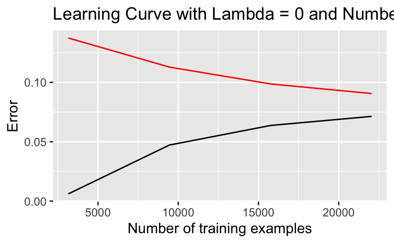

```r
lambda = 0
maxit = 100
num_labels = 10
learningCurve(X_train, y_train, X_val, y_val, lambda, maxit, epsilon, num_labels)
```

With all features, the one-vs-all logistic regression runs slowly. Its learning curve took about 10 mins. So we will use PCA to speed up the learning process.

## PCA

```r
PCA = pca(X_train)
U = PCA$U
D = PCA$D
```

```r
p = 0.99
K = selectNumComponent(D, p)
K
```

```
[1] 330
```

```r
Z_train = projectData(X_train, U, K)
Z_val = projectData(X_val, U, K)
Z_test = projectData(X_test, U, K)
```

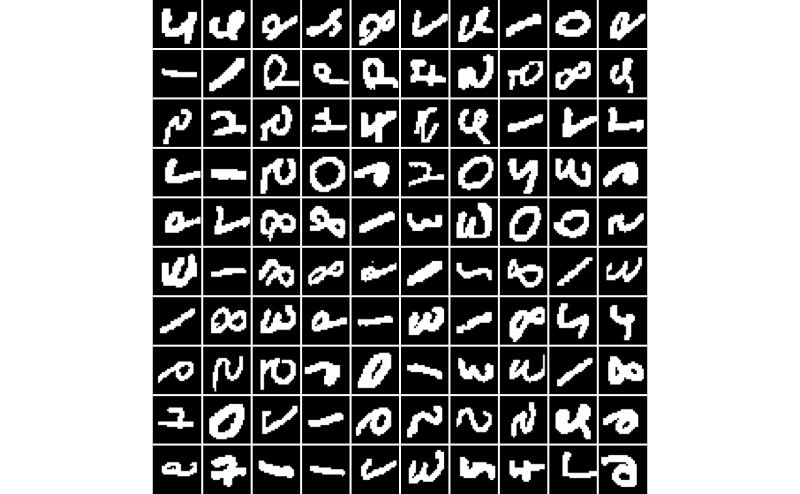

```r
library(EBImage)
L = list()
for (i in 1:100) {
  x_i = matrix(X_train[i,], nrow = sqrt(ncol(X_train)), ncol = sqrt(ncol(X_train)), byrow = T)
  L[[i]] = x_i
}
img = combine(L[1:100])
display(img, method = "raster", all = T)
```

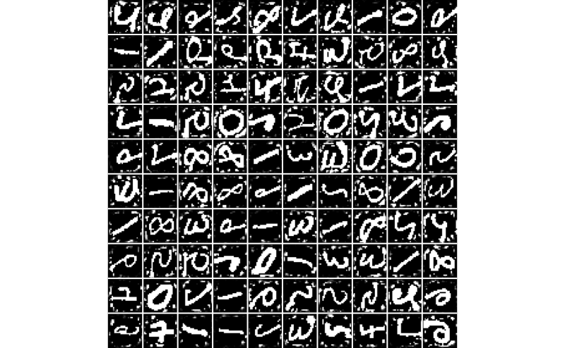

```r
X_train_rec = recoverData(Z_train, U, K)
L1 = list()
for (i in 1:100) {
  x_i = matrix(X_train_rec[i,], nrow = sqrt(ncol(X_train_rec)), ncol = sqrt(ncol(X_train_rec)), byrow = T)
  L1[[i]] = x_i
}
img_rec = combine(L1[1:100])
display(img_rec, method = "raster", all = T)
```

## One-vs-all logistic regression on PCA features

```
$error_train
[1] 0.1542857 0.1853968 0.1915556 0.1948299

$error_val
[1] 0.2198810 0.2108333 0.2085714 0.2072619

$figure
```

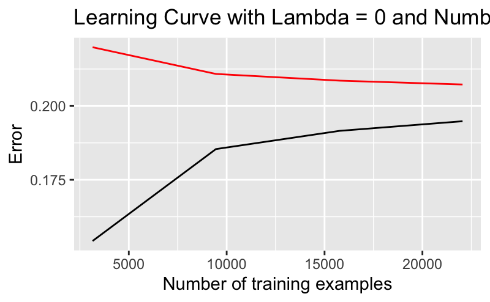

```r
lambda = 0
maxit = 100
num_labels = 10
learningCurve(Z_train, y_train, Z_val, y_val, lambda, maxit, epsilon, num_labels)
```

```r
num_labels = 10
lambda = 0
maxit = 500
modelOneVsAllLog = OneVsAll(Z_train, y_train, num_labels, lambda, maxit)
thetaOneVsAllLog = modelOneVsAllLog$par
paste("One-Vs-All Logistic Regression with PCA 99% of Variance Retained:", mean(predictOneVsAll(Z_test, thetaOneVsAllLog) == y_test))
```

```
[1] "One-Vs-All Logistic Regression with PCA 99% of Variance Retained: 0.80952380952381"
```

## Neural networks

```
$error_train
[1] 0.05650794 0.05597884 0.05180952 0.05215420

$error_val
[1] 0.12285714 0.09928571 0.09154762 0.08476190

$figure
```

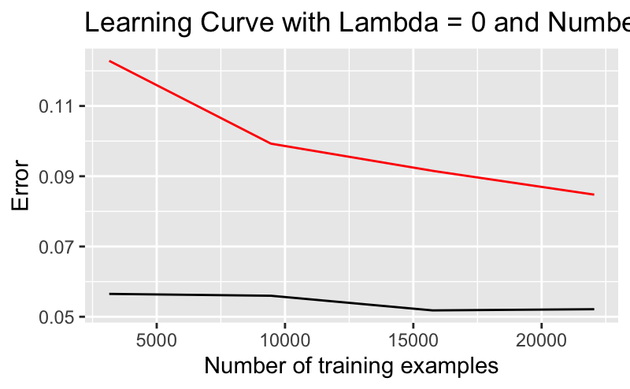

```r
lambda = 0
maxit = 100
num_labels = 10
hidden_layer_size = 50
learningCurve(Z_train, y_train, Z_val, y_val, lambda, maxit, epsilon, num_labels, hidden_layer_size)
```

It indicates high variance and low bias.

```
$error_train
[1] 0.05444444 0.05146825 0.05206349

$error_val
[1] 0.08142857 0.07523810 0.08178571

$figure
```

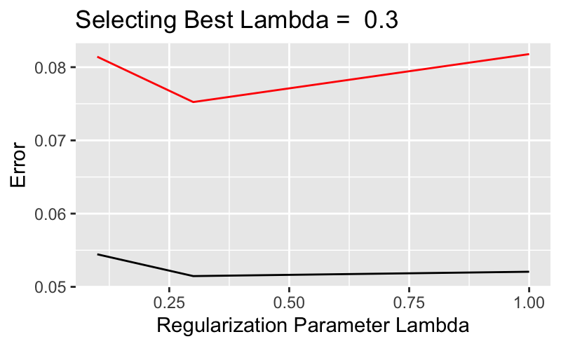

```r
lambda_vec = c(0.1,0.3,1)
maxit = 100
num_labels = 10
hidden_layer_size = 50
selectLambda(Z_train, y_train, Z_val, y_val, lambda_vec,
                        maxit, epsilon, num_labels, hidden_layer_size)
```

```r
input_layer_size = ncol(Z_train)
hidden_layer_size = 50
num_labels = 10
lambda = 0.3
maxit = 500
modelNNet = nnLearning(input_layer_size, hidden_layer_size, num_labels, Z_train, y_train, lambda, maxit)
```

[output not shown]